# Clustering of Danish in the United States

Ida Bække Johannesen & Laura Bang Jensen

07-06-2024

## Packages

First, we have created the option of installing all of the packages, that is needed in this file. Right now they are commented out using ‘#’. That can be removed before running the code chunk, if you are missing any of the packages.

```r
#install.packages("knitr")
#install.packages("rmdformats")
#install.packages("hexbin")
#install.packages("sf")
#install.packages("tidyverse")
#install.packages("dplyr")
#install.packages("spdep")
#install.packages("tmap")
#install.packages("gridExtra")
```

Then the packages are being loaded.

```r
library(knitr)
library(rmdformats)
library(hexbin)
library(sf)
library(tidyverse)
library(dplyr)
library(spdep)
library(tmap)
```

## load data

We have created two datasets manually, containing the data that is used in this code. We load them separately and them combine them.

```r
immigrants_1920 <- read.csv2("../data/1920.csv")
speakers_2009 <-  read.csv2("../data/danish_speakers_2009.csv")

# merging the two datasets by "state" column
combined_data <- merge(x = immigrants_1920, y = speakers_2009, by = "state")
```

## plotting maps

For plotting maps of the United States, firstly we load a shapefile of the US. We then manipulate the map by cutting out any non-state US territories and creating a bounding box, that we can use to crop the map to an appropriate size.

```r
# load a shape file of the US
state_map <- read_sf("../data/tl_2023_us_state/tl_2023_us_state.shp")

# cut out the territories
clean_state <- state_map[!grepl("9", state_map$REGION),]

# creating bounding box
bbox <- st_bbox(c(xmin = -169.5312996, ymin = -24.894595, xmax = -30.93457, ymax = 71.635547))

# cropping according to bounding box
crop_map <- st_crop(clean_state, bbox)
```

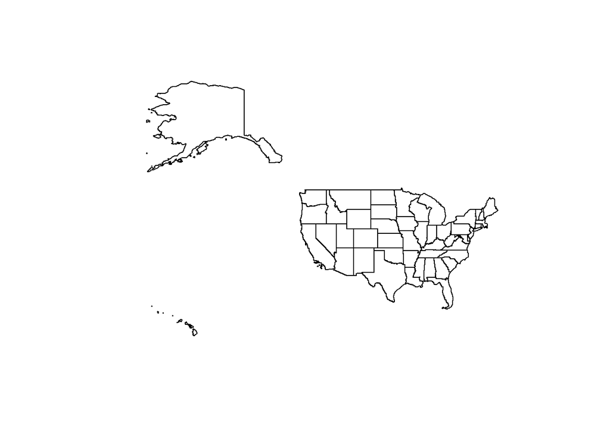

```r
# plotting the shapefile to check it
plot(crop_map$geometry)
```

Then we merge the data with the shapefile, so the geometry of the state polygons fits with the the data we have. After that, we transform it to a simple feature, which is necessary to be able to plot it later. We are interested at looking at the data in three different ways: as raw numbers, as a percentage relative to the overall population, and as the number of immigrants/speakers per square kilometer of the state. To do that we need to calculate the relative population and the population of Danes per square kilometer.

```r
# merging the dataset we have created with the shapefile
geometry_data <- merge(combined_data, crop_map, by.x = "state", by.y = "NAME")

# transforming it into a simple feature
transformed_data <- st_as_sf(geometry_data)

# add columns with relative population of Danes compared to overall population
transformed_data$rel_pop_1920 <- transformed_data$danish_immigrants/transformed_data$population_1920*100
transformed_data$rel_pop_2009 <- transformed_data$danish_speakers/transformed_data$population_2009*100

# add columns with population of Danes per square kilometer
transformed_data$rel_area_1920 <- transformed_data$danish_immigrants/transformed_data$area
transformed_data$rel_area_2009 <- transformed_data$danish_speakers/transformed_data$area
```

```r
# defining a color palette for the plots
myPalette <- c("#EDF8B1", "#C7E9B4", "#7FCDBB","#41B6C4", "#1D91C0", "#225EA8")
```

First we plot the Danish immigrants from 1920 in three different ways.

```
## Some legend labels were too wide. These labels have been resized to 0.59, 0.59, 0.59, 0.54, 0.50. Increase legend.width (argument of tm_layout) to make the legend wider and therefore the labels larger.
```

```
## Some legend labels were too wide. These labels have been resized to 0.59, 0.59, 0.59, 0.59, 0.59, 0.59. Increase legend.width (argument of tm_layout) to make the legend wider and therefore the labels larger.
## Some legend labels were too wide. These labels have been resized to 0.59, 0.59, 0.59, 0.59, 0.59, 0.59. Increase legend.width (argument of tm_layout) to make the legend wider and therefore the labels larger.
```

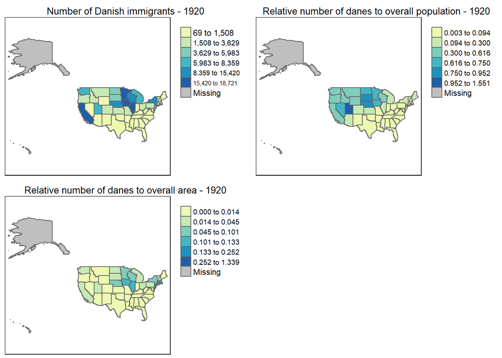

```r
a1 <- tm_shape(transformed_data) +
      tm_polygons(col = "danish_immigrants", palette = myPalette, style = "jenks", n=6, title = "") +
      tm_layout(legend.outside = TRUE, main.title = "Number of Danish immigrants - 1920", main.title.size = 0.8,
                main.title.position = "center")
b1 <- tm_shape(transformed_data) +
      tm_polygons(col = "rel_pop_1920", palette = myPalette, style = "jenks", n=6, title = "") +
      tm_layout(legend.outside = TRUE, main.title = "Relative number of danes to overall population - 1920",
                main.title.size = 0.8, main.title.position = "center")
c1 <- tm_shape(transformed_data) +
      tm_polygons(col = "rel_area_1920", palette = myPalette, style = "jenks", n=6, title = "") +
      tm_layout(legend.outside = TRUE, main.title = "Relative number of danes to overall area - 1920",
                main.title.size = 0.8, main.title.position = "center")

# plot them all together
tmap_arrange(a1, b1, c1)
```

Then we plot the Danish speakers from 2009 in three different ways.

```
## Some legend labels were too wide. These labels have been resized to 0.59, 0.59. Increase legend.width (argument of tm_layout) to make the legend wider and therefore the labels larger.
```

```
## Some legend labels were too wide. These labels have been resized to 0.59, 0.59, 0.59, 0.59, 0.59, 0.59. Increase legend.width (argument of tm_layout) to make the legend wider and therefore the labels larger.
## Some legend labels were too wide. These labels have been resized to 0.59, 0.59, 0.59, 0.59, 0.59, 0.59. Increase legend.width (argument of tm_layout) to make the legend wider and therefore the labels larger.
```

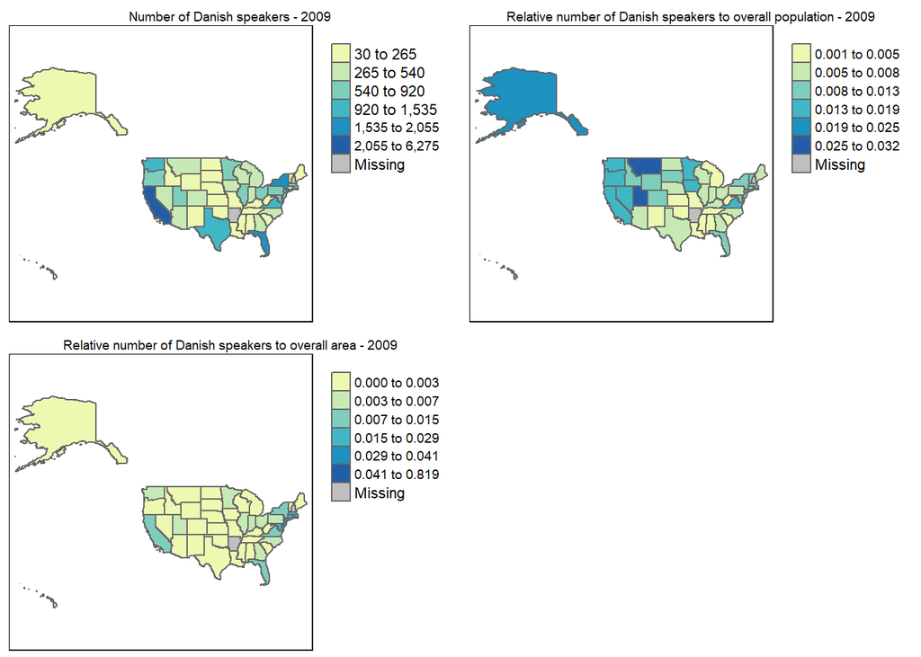

```r
a2 <- tm_shape(transformed_data) +
      tm_polygons(col = "danish_speakers", palette = myPalette, style = "jenks", n=6, title = "") +
      tm_layout(legend.outside = TRUE, main.title = "Number of Danish speakers - 2009", main.title.size = 0.6,
                main.title.position = "center")
b2 <- tm_shape(transformed_data) +
      tm_polygons(col = "rel_pop_2009", palette = myPalette, style = "jenks", n=6, title = "") +
      tm_layout(legend.outside = TRUE, main.title = "Relative number of Danish speakers to overall population - 2009",
                main.title.size = 0.6, main.title.position = "center")
c2 <- tm_shape(transformed_data) +
      tm_polygons(col = "rel_area_2009", palette = myPalette, style = "jenks", n=6, title = "") +
      tm_layout(legend.outside = TRUE, main.title = "Relative number of Danish speakers to overall area - 2009",
                main.title.size = 0.6, main.title.position = "center")

# plot them all together
tmap_arrange(a2, b2, c2)
```

## plotting hexbin maps

To create a different type of visualization, we have decided to create hexbin maps over the same data. First we load a file with the hexbin geometry, and clean up the names in the column where they have the state names. That is necessary to be able to merge it with our data.

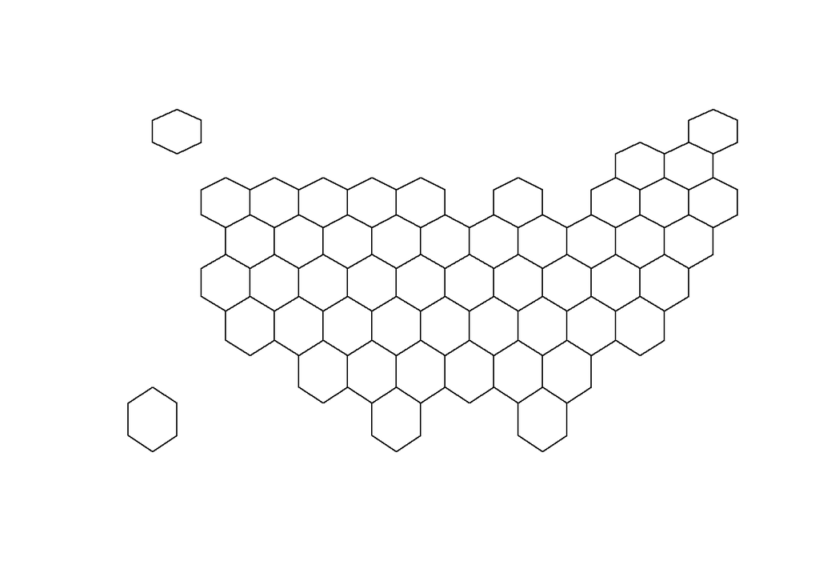

```r
# load file with hexbin geometry
us_hex <- read_sf("../data/us_states_hexgrid.geojson")

# cleaning up the state names
us_hex <- us_hex %>%
  mutate(google_name = gsub(" \\(United States\\)", "", google_name))

# plot hexbins to check it
plot(st_geometry(us_hex))
```

Then we merge the hexbin file with our data, and transform it into a simple feature. We once again calculate the relative population and the population of Danes per square kilometer for both years, in order to add these as extra columns in our dataset.

```r
# merge the dataset with the file with hexbin geometries
hex_data <- merge(combined_data, us_hex, by.x = "state", by.y = "google_name")

# transform into a simple feature
transformed_hex <- st_as_sf(hex_data)

# add columns with relative population of danes compared to overall population
transformed_hex$rel_pop_1920 <- transformed_hex$danish_immigrants/transformed_hex$population_1920*100
transformed_hex$rel_pop_2009 <- transformed_hex$danish_speakers/transformed_hex$population_2009*100

# add columns with population of danes per square kilometer
transformed_hex$rel_area_1920 <- transformed_hex$danish_immigrants/transformed_hex$area
transformed_hex$rel_area_2009 <- transformed_hex$danish_speakers/transformed_hex$area
```

Then we can begin to create the hexbin plots that we need.

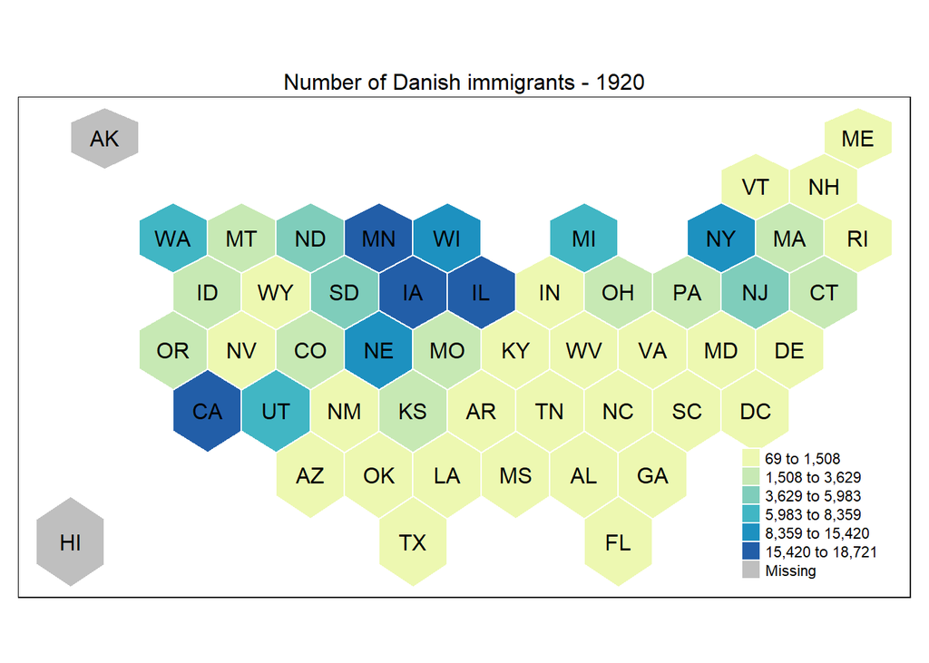

```r
# plot number of Danish immigrants - 1920
tm_shape(transformed_hex) +
      tm_polygons(col = "danish_immigrants", palette = myPalette, style = "jenks", n=6, border.col = "white",
                  title = "") +
      tm_text(text = "iso3166_2", col = "black", size = 1) +
      tm_layout(main.title = "Number of Danish immigrants - 1920", main.title.size = 1,
                main.title.position = "center")
```

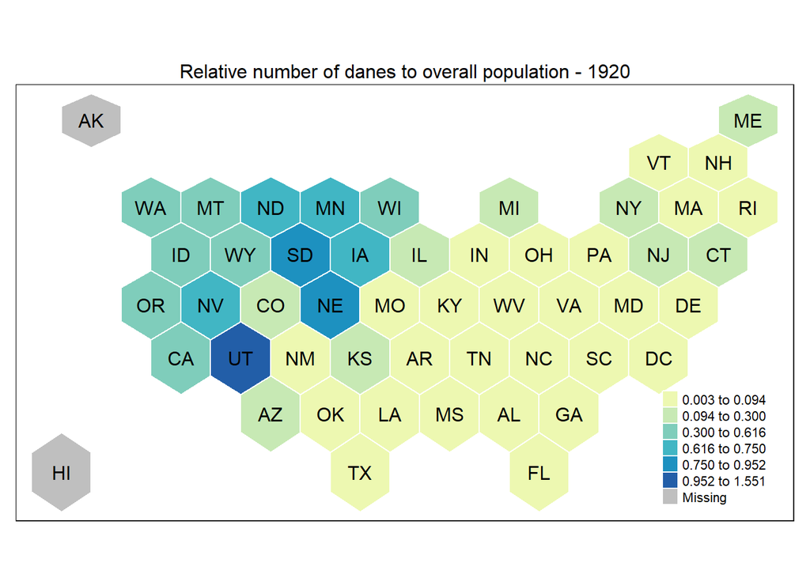

```r
# plot relative number of danes to overall population - 1920
tm_shape(transformed_hex) +
      tm_polygons(col = "rel_pop_1920", palette = myPalette, style = "jenks", n=6, border.col = "white",
                  title = "") +
      tm_text(text = "iso3166_2", col = "black", size = 1) +
      tm_layout(main.title = "Relative number of danes to overall population - 1920", main.title.size = 1,
                main.title.position = "center")
```

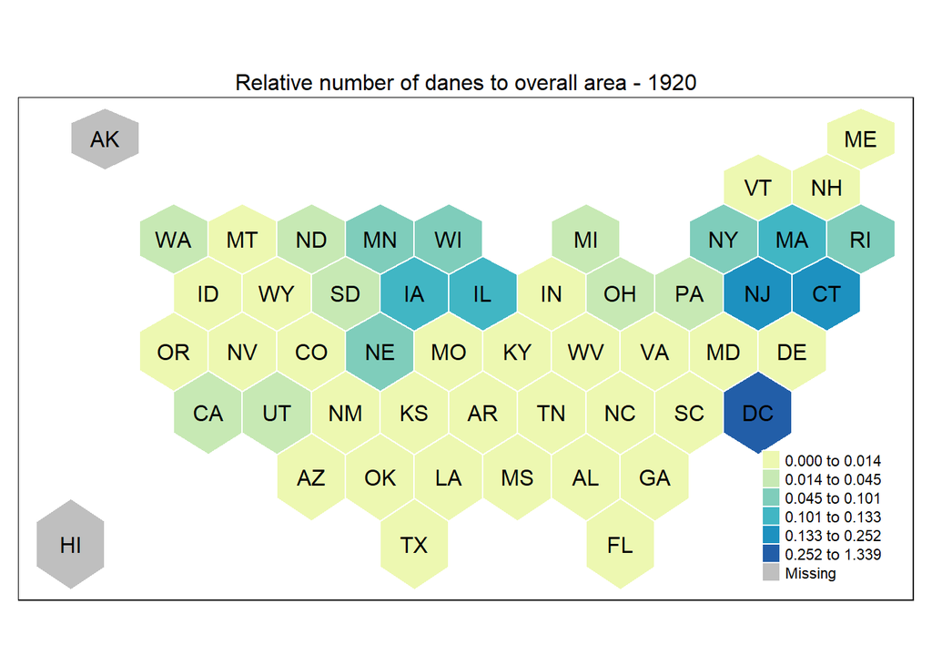

```r
# plot relative number of danes to overall area - 1920
tm_shape(transformed_hex) +
      tm_polygons(col = "rel_area_1920", palette = myPalette, style = "jenks", n=6, border.col = "white",
                  title = "") +
      tm_text(text = "iso3166_2", col = "black", size = 1) +
      tm_layout(main.title = "Relative number of danes to overall area - 1920", main.title.size = 1,
                main.title.position = "center")
```

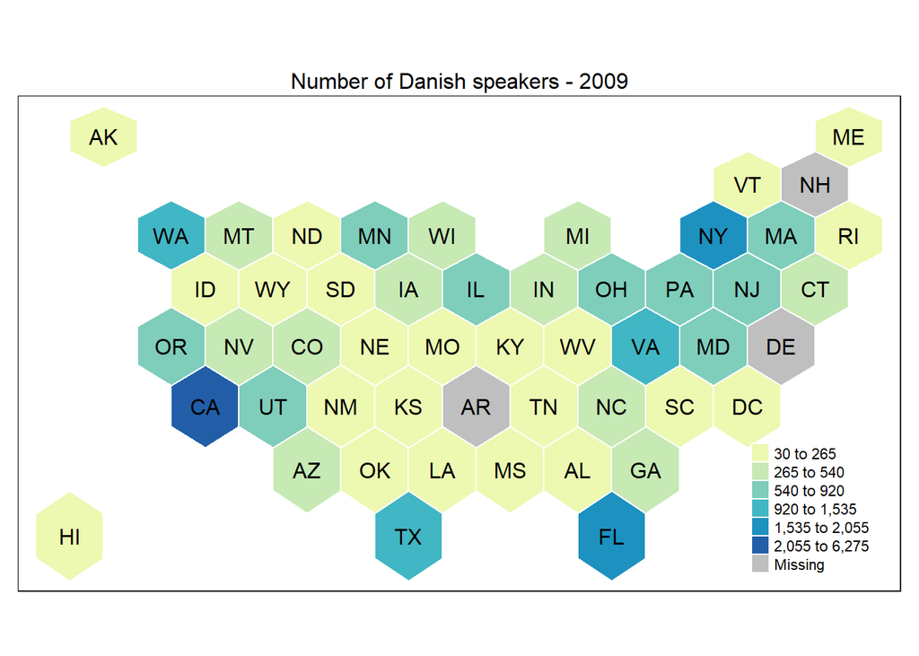

```r
# plot number of Danish speakers - 2009
tm_shape(transformed_hex) +
      tm_polygons(col = "danish_speakers", palette = myPalette, style = "jenks", n=6, border.col = "white",
                  title = "") +
      tm_text(text = "iso3166_2", col = "black", size = 1) +
      tm_layout(main.title = "Number of Danish speakers - 2009", main.title.size = 1,
                main.title.position = "center")
```

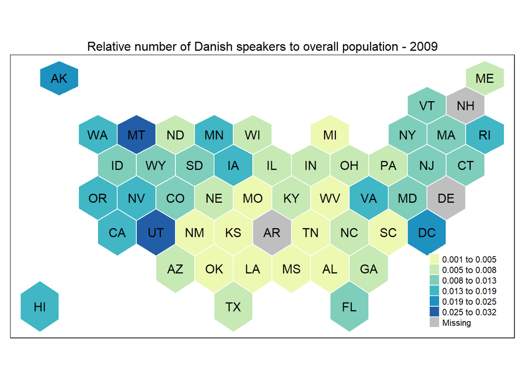

```r
# plot relative number of Danish speakers to overall population - 2009
tm_shape(transformed_hex) +
      tm_polygons(col = "rel_pop_2009", palette = myPalette, style = "jenks", n=6, border.col = "white",
                  title = "") +
      tm_text(text = "iso3166_2", col = "black", size = 1) +
      tm_layout(main.title = "Relative number of Danish speakers to overall population - 2009", main.title.size = 1,
                main.title.position = "center")
```

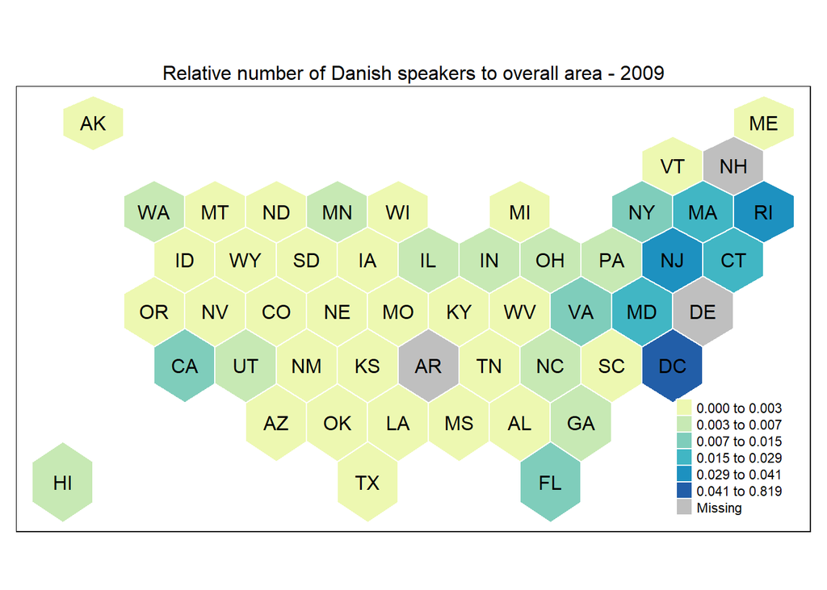

```r
# plot relative number of Danish speakers to overall area - 2009
tm_shape(transformed_hex) +
      tm_polygons(col = "rel_area_2009", palette = myPalette, style = "jenks", n=6, border.col = "white",
                  title = "") +
      tm_text(text = "iso3166_2", col = "black", size = 1) +
      tm_layout(main.title = "Relative number of Danish speakers to overall area - 2009", main.title.size = 1,
                main.title.position = "center")
```

## Calculate neighbors

To figure out whether there is a geographical clustering in the data, we find nearest neighbors, both using queen adjacency and just finding the four nearest. We also calculate Moran’s I and run a Monte Carlo simulation, to determine the statistical significance of clustering.

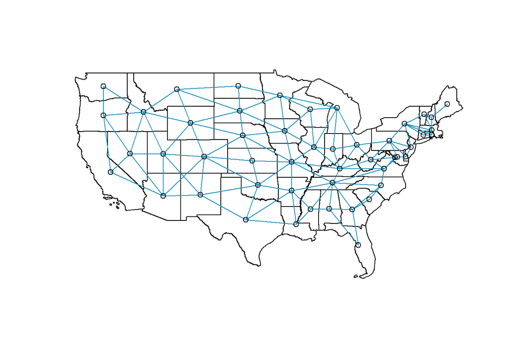

```r
# calculate neighbors for 1920 data - queen adjacency

# remove rows with NA in rel_pop_1920
data_filtered_1920 <- transformed_data[!is.na(transformed_data$rel_pop_1920), ]

# calculate neighbor states
nb_qa_1920 <- poly2nb(data_filtered_1920$geometry)

# get centroids
state_centers_1920 <- st_coordinates(st_centroid(data_filtered_1920$geometry))

# plot nearest neighbors
plot(data_filtered_1920$geometry); plot(nb_qa_1920, state_centers_1920, col = "#1D91C0",add = TRUE)
```

```r
# run Moran's I on filtered data
moran.test(data_filtered_1920$rel_pop_1920, nb2listw(nb_qa_1920, style = "W",zero.policy=TRUE), zero.policy=TRUE)
```

```
##
##  Moran I test under randomisation
##
## data:  data_filtered_1920$rel_pop_1920
## weights: nb2listw(nb_qa_1920, style = "W", zero.policy = TRUE)
##
## Moran I statistic standard deviate = 6.317, p-value = 1.334e-10
## alternative hypothesis: greater
## sample estimates:
## Moran I statistic       Expectation          Variance
##       0.558884477      -0.020833333       0.008422014
```

```r
# monte carlo simulation
moran.mc(data_filtered_1920$rel_pop_1920,
         nb2listw(nb_qa_1920, zero.policy=TRUE),
         zero.policy=TRUE, nsim = 999)
```

```
##
##  Monte-Carlo simulation of Moran I
##
## data:  data_filtered_1920$rel_pop_1920
## weights: nb2listw(nb_qa_1920, zero.policy = TRUE)
## number of simulations + 1: 1000
##
## statistic = 0.55888, observed rank = 1000, p-value = 0.001
## alternative hypothesis: greater
```

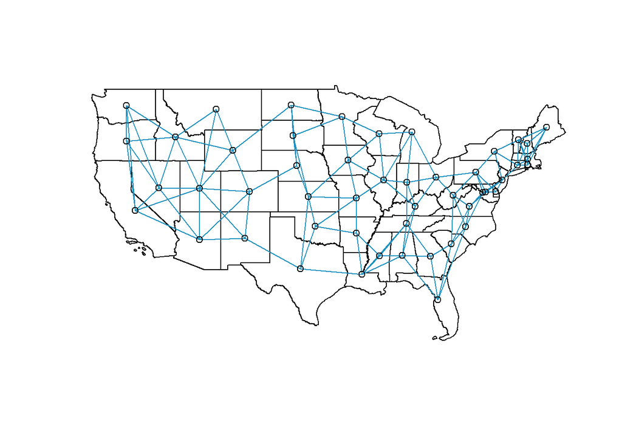

```r
# calculate neighbors for 1920 data - nearest neighbors

# calculate neighbor states
nb_nn_1920 <- knn2nb(knearneigh(state_centers_1920, k = 4))

# plot nearest neighbors
plot(data_filtered_1920$geometry); plot(nb_nn_1920, state_centers_1920, col = "#1D91C0",add = TRUE)
```

```r
# run Moran's I on filtered data
moran.test(data_filtered_1920$rel_pop_1920, nb2listw(nb_nn_1920, style = "W",zero.policy=TRUE), zero.policy=TRUE)
```

```
##
##  Moran I test under randomisation
##
## data:  data_filtered_1920$rel_pop_1920
## weights: nb2listw(nb_nn_1920, style = "W", zero.policy = TRUE)
##
## Moran I statistic standard deviate = 7.2474, p-value = 2.124e-13
## alternative hypothesis: greater
## sample estimates:
## Moran I statistic       Expectation          Variance
##       0.611394310      -0.020833333       0.007609911
```

```r
# monte carlo simulation
moran.mc(data_filtered_1920$rel_pop_1920,
         nb2listw(nb_nn_1920, zero.policy=TRUE),
         zero.policy=TRUE, nsim = 999)
```

```
##
##  Monte-Carlo simulation of Moran I
##
## data:  data_filtered_1920$rel_pop_1920
## weights: nb2listw(nb_nn_1920, zero.policy = TRUE)
## number of simulations + 1: 1000
##
## statistic = 0.61139, observed rank = 1000, p-value = 0.001
## alternative hypothesis: greater
```

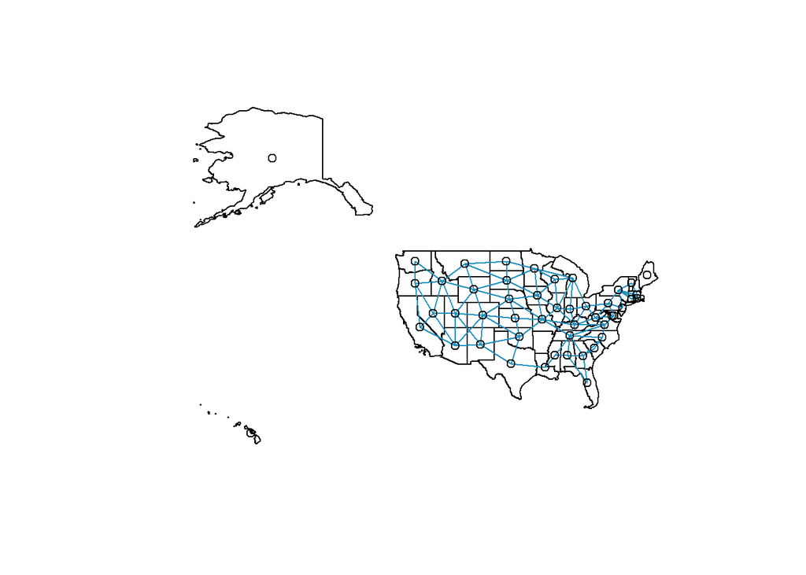

```r
# calculate neighbors for 2009 data - queen adjacency

# remove rows with NA in rel_pop_2009
data_filtered_2009 <- transformed_data[!is.na(transformed_data$rel_pop_2009), ]

# calculate neighbor states
nb_qa_2009 <- poly2nb(data_filtered_2009$geometry)

# get centroids
state_centers_2009 <- st_coordinates(st_centroid(data_filtered_2009$geometry))

# plot nearest neighbors
plot(data_filtered_2009$geometry); plot(nb_qa_2009, state_centers_2009, col = "#1D91C0",add = TRUE)
```

```r
# run Moran's I on filtered data
moran.test(data_filtered_2009$rel_pop_2009, nb2listw(nb_qa_2009, style = "W",zero.policy=TRUE), zero.policy=TRUE)
```

```
##
##  Moran I test under randomisation
##
## data:  data_filtered_2009$rel_pop_2009
## weights: nb2listw(nb_qa_2009, style = "W", zero.policy = TRUE)
## n reduced by no-neighbour observations
##
## Moran I statistic standard deviate = 3.143, p-value = 0.0008361
## alternative hypothesis: greater
## sample estimates:
## Moran I statistic       Expectation          Variance
##       0.284469360      -0.022727273       0.009553022
```

```r
# monte carlo simulation
moran.mc(data_filtered_2009$rel_pop_2009,
         nb2listw(nb_qa_2009, zero.policy=TRUE),
         zero.policy=TRUE, nsim = 999)
```

```
##
##  Monte-Carlo simulation of Moran I
##
## data:  data_filtered_2009$rel_pop_2009
## weights: nb2listw(nb_qa_2009, zero.policy = TRUE)
## number of simulations + 1: 1000
##
## statistic = 0.28447, observed rank = 999, p-value = 0.001
## alternative hypothesis: greater
```

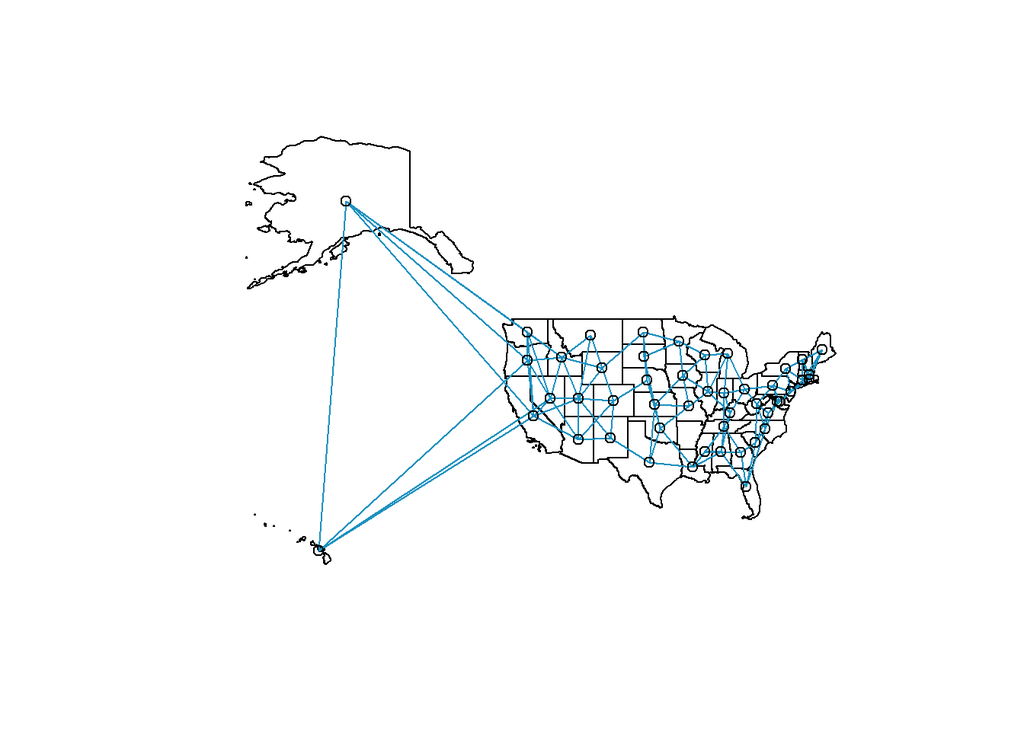

```r
# calculate neighbors for 2009 data - nearest neighbors

# calculate neighbor states
nb_nn_2009 <- knn2nb(knearneigh(state_centers_2009, k = 4))

# plot nearest neighbors
plot(data_filtered_2009$geometry); plot(nb_nn_2009, state_centers_2009, col = "#1D91C0",add = TRUE)
```

```r
# run Moran's I on filtered data
moran.test(data_filtered_2009$rel_pop_2009, nb2listw(nb_nn_2009, style = "W",zero.policy=TRUE), zero.policy=TRUE)
```

```
##
##  Moran I test under randomisation
##
## data:  data_filtered_2009$rel_pop_2009
## weights: nb2listw(nb_nn_2009, style = "W", zero.policy = TRUE)
##
## Moran I statistic standard deviate = 4.8536, p-value = 6.063e-07
## alternative hypothesis: greater
## sample estimates:
## Moran I statistic       Expectation          Variance
##       0.407649797      -0.021276596       0.007809834
```

```r
# monte carlo simulation
moran.mc(data_filtered_2009$rel_pop_2009,
         nb2listw(nb_nn_2009, zero.policy=TRUE),
         zero.policy=TRUE, nsim = 999)
```

```
##
##  Monte-Carlo simulation of Moran I
##
## data:  data_filtered_2009$rel_pop_2009
## weights: nb2listw(nb_nn_2009, zero.policy = TRUE)
## number of simulations + 1: 1000
##
## statistic = 0.40765, observed rank = 999, p-value = 0.001
## alternative hypothesis: greater
```